# Vector Data Analysis using R

## Objectives

1. Hand on use of the sf package to read and manipulate spatial data.
2. Familiarize oneself with some commonly used dplyr functions.
3. Perform table and spatial join on spatial and non-spatial data.
4. Learn basic mapping skills using `tmap()` and `leaflet()`.

## Overview

The sf package is very well documented. It has well-built functionalities that allow for easy vector geographic data processing and manipulation. It has alot of similarities with PostGis, because both supports objects and functions specified in the **Open Geospatial Consortium(OGC)** and refers to formal standards(ISO 19125-1:20040). Leaflet is an open source javascript library for web mapping, it is usually use in conjuction with **HTML(HyperText Markup Language)** and **CSS (Casacading Style Sheet)**.It is very fuctional and effective for interactive web mapping.The tidyverse package is yet another powerful tool for data wrangling and processing in R.It is made up of a collection of other packages including dplyr,tidyr,readr,purr etc.

Lets load the following libraries.

```r
library(sf)
library(tidyverse)
library(ggplot2)
library(tmap)
library(leaflet)
library(htmltools)
library(pals)
```

Lets load in all our data using `read_sf()` and `read.csv()`.

```r
#You would first need to setup your working directory
#setwd("File Path")
GhanaRegion<- read_sf("GhanaRegion.shp")
GhanaDistrict <- read_sf("districts.shp")
ClassRoster <- read.csv("roster.csv")
```

## Checking and Setting CRS

The coordinate refrence system(CRS) defines how the two-dimensional spatial object or element relate to the surface of the earth. In this workflow we would be using the datum WGS84 with projection unit of Longitude and Latitude.

Lets check the verious class and CRS of the *Spatial Objects* loaded using the `class()` function.

```r
class(GhanaRegion)
[1] "sf"         "tbl_df"     "tbl"        "data.frame"
class(GhanaDistrict)
[1] "sf"         "tbl_df"     "tbl"        "data.frame"

st_crs(GhanaRegion)$epsg
[1] 4326
st_crs(GhanaDistrict)$epsg
[1] NA

st_is_longlat(GhanaRegion)
[1] TRUE
st_is_longlat(GhanaDistrict)
[1] NA
```

They are all of class **sf**, thats what we want.

The **GhanaDistrict** spatial Object has no CRS, hence the need to set it.

```r
GhanaDistrict <-st_set_crs(GhanaDistrict,4326)

#Lets check again to be sure
st_crs(GhanaDistrict)$epsg
[1] 4326
```

Note, the projections are in **longlat(WGS84)**, since we wouldn’t be computing any distance or area measurements, there is no need tranforming or reprojecting.

## Table Join

This allows us to join the attribute data to the spatial object(**vector**) based on a common feature(key) between the two objects.

Lets create a table join specifically an **innerjoin**.This would narrow down the data to districts that we are more interested in working with.

```r
nrow(ClassRoster) #Is 30 rows, so we are not expecting anything less or more than that in our join.
[1] 30


MphilDistricts <- inner_join(ClassRoster,GhanaDistrict, by= c("District"="district"))

nrow(MphilDistricts) #The output gives 29 rows, we are short of one.
[1] 29

#Lets try to find out which sample in the ClassRoster was left out.
dplyr::setdiff(ClassRoster$District,GhanaDistrict$district)
[1] "Wasa Amenfi West Municipal"
```

We notice Wasa Amenfi West Municipal was left out. Lets find out using the `str_which()` function.

```r
LeftOutDistrict<- stringr::str_which(GhanaDistrict$district,pattern= "Amenfi West Municipal")#Output indicate row 19.


#Within the DistrictCentroid it is located at row 19(19th sample)

dplyr::as_tibble(GhanaDistrict[LeftOutDistrict,])
# A tibble: 1 x 4
  district         capital  region                                      geometry
  <chr>            <chr>    <chr>                             <MULTIPOLYGON [°]>
1 Wassa Amenfi We~ Asankra~ Weste~ (((-2.425311 6.099912, -2.424804 6.099697, -~
```

Note the spelling of the **Wassa(double ‘ss’)** as compared to a **Wasa(single ‘s’)** in the ClassRoster.

```r
ClassRoster$District <- str_replace(ClassRoster$District, pattern ="Wasa Amenfi West Municipal",
                           replacement = "Wassa Amenfi West Municipal")

#We have it corrected now
head(ClassRoster[29,2])
[1] "Wassa Amenfi West Municipal"
```

We can see that the spelling is now corrected.

We perform the innerjoin again with the function `inner_join()`. Note; the spatial object would have to begin first, otherwise output would be a dataframe.

```r
MphilDistricts <- dplyr::inner_join(GhanaDistrict,ClassRoster, by= c("district"="District"))

#Lets reorder the colums, by relocating the geometry column to the tail-end
MphilDistricts<- MphilDistricts %>%
  relocate(geometry, .after= Region)


#Lets verify join and re-ordering of the column
dplyr::as_tibble(head(MphilDistricts))
# A tibble: 6 x 6
  district     capital  region Hometown Region                          geometry
  <chr>        <chr>    <chr>  <fct>    <fct>                 <MULTIPOLYGON [°]>
1 Oforikrom M~ Oforikr~ Ashan~ Anwomaso "Asha~ (((-1.589643 6.692048, -1.589143~
2 Oforikrom M~ Oforikr~ Ashan~ Ayigya   "Asha~ (((-1.589643 6.692048, -1.589143~
3 Ellembelle   Nkrofu   Weste~ Kikam    "West~ (((-2.368165 5.377938, -2.367797~
4 Wassa East   Daboase  Weste~ Baboase  "West~ (((-1.615376 5.515792, -1.615368~
5 Wassa Amenf~ Asankra~ Weste~ Asankre~ "West~ (((-2.425311 6.099912, -2.424804~
6 Cape Coast ~ Cape Co~ Centr~ Adisadel "Cent~ (((-1.21181 5.117897, -1.21249 5~
```

The number of rows is now 30 as compared to before,join is perfectly done.

We have the **Region** and **region** column showing.They hold the same data , lets set one to NULL.

```r
MphilDistricts$Region <- NULL #sets the Region column to NULL

#Rename all variable to lowercase just for uniformity
names(MphilDistricts)<- tolower(names(MphilDistricts))

as_tibble(head(MphilDistricts)) #prints out the first 6 samples(rows).
# A tibble: 6 x 5
  district      capital  region  hometown                               geometry
  <chr>         <chr>    <chr>   <fct>                        <MULTIPOLYGON [°]>
1 Oforikrom Mu~ Oforikr~ Ashanti Anwomaso (((-1.589643 6.692048, -1.589143 6.69~
2 Oforikrom Mu~ Oforikr~ Ashanti Ayigya   (((-1.589643 6.692048, -1.589143 6.69~
3 Ellembelle    Nkrofu   Western Kikam    (((-2.368165 5.377938, -2.367797 5.37~
4 Wassa East    Daboase  Western Baboase  (((-1.615376 5.515792, -1.615368 5.51~
5 Wassa Amenfi~ Asankra~ Western Asankre~ (((-2.425311 6.099912, -2.424804 6.09~
6 Cape Coast M~ Cape Co~ Central Adisadel (((-1.21181 5.117897, -1.21249 5.1172~
```

Lets compute the top 3 districts with highest number of Mphil students 2019-2021

```r
Top3DistrictCount <- st_drop_geometry(MphilDistricts) %>%
  select(district) %>%
  group_by(district) %>%
  tally(sort = TRUE, name = "count") %>%
  top_n(3, count)

as_tibble(Top3DistrictCount)
# A tibble: 3 x 2
  district             count
  <chr>                <int>
1 Ho Municipal             2
2 Mfantseman Municipal     2
3 Oforikrom Municipal      2
```

From the above table summary, it is deduce that Ho Municipal,Mfantseman Municipal and Oforikrom Municipal were each represented by two students, with all other Municipal and Districts represented by one student.

## Spatial Join

This communicates how the spatial objects relates based on their location(**x** and **y**) coordinates and how they interact at that location(spatial overlay).

Lets create a spatial join between the Region and District shape files. This allow us to have all information as one unit.

```r
#Spatial join between GhanaShape and MphilDistrict

RegionDistrict <- sf::st_join(GhanaRegion,MphilDistricts)

# Lets relocate the **geometry** column to the tail-end
RegionDistrict<- RegionDistrict %>%
  relocate(geometry, .after= hometown)

RegionDistrict$region <- NULL #sets the region column to NULL

#Rename all variable to lowercase just for uniformity
names(RegionDistrict)<- tolower(names(RegionDistrict))
```

## Centroids

This enable us create a single central point of the various region polygon. Thats allowing us to easily plot the regional count in their respective region polygon.

Lets now look at student count at the regional level, and see wether they are any surprises.Note; this are not necessarily where student are staying or residing, but the birth district of each student.

```r
MphilRegionalCount <- RegionDistrict %>%
  select(regions) %>%
  group_by(regions) %>%
  tally(sort = TRUE, name = "region_count")

# Lets  generates the centroids for easy plotting.
# we would use this centroids as a layer for the leaflet map.

RegionCentroids <- st_centroid(MphilRegionalCount)
```

## Column Chart and Proportional Symbol Map

The column chart depicts the raw counts of the students in the various regions within Ghana.

Lets design a basic column chart using the function `ggplot()`.

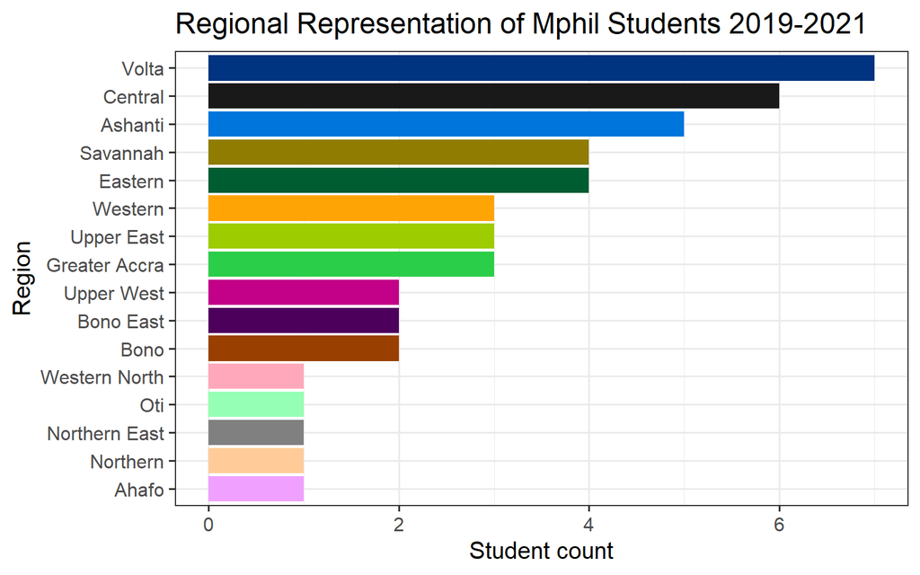

```r
#lets create our own colour/fill palette using pals
RegionalColors <- as.vector(pals::alphabet(n=16))

#Lets reperesnt it on a basic column / bar plot.
RegionCentroids %>%
  ggplot(aes(x=fct_reorder(regions,region_count), y=region_count, fill=regions))+
  geom_col()+guides(fill=FALSE)+
  coord_flip()+
  ggtitle("Regional Representation of Mphil Students 2019-2021")+
  theme(plot.title = element_text(size=14,family="Tahoma",face="bold",hjust = 0.5))+
  theme_bw(base_size = 15)+
  labs(x="Region",y= "Student count")+
  scale_fill_manual(values = RegionalColors)
```

Lets now map the various **region_count**/ **population** of Mphil students within their regional boundaries. (note;this are just raw count). This is represented as a proportional symbol map below.

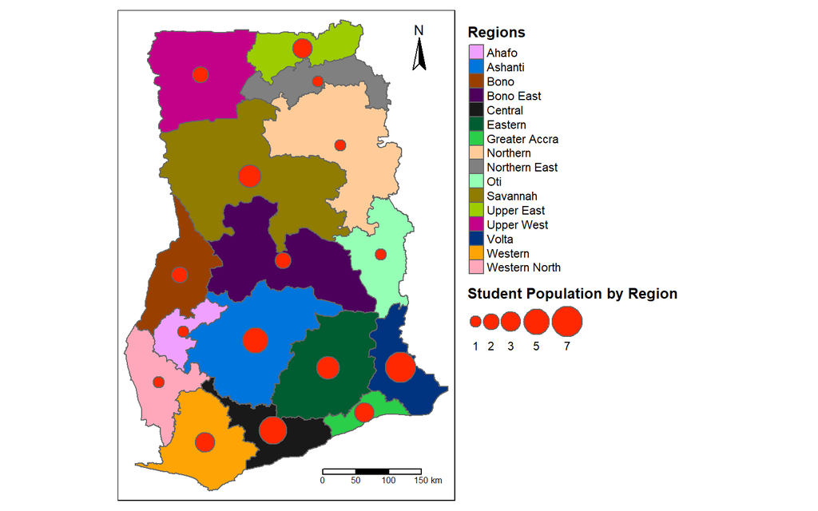

```r
## A static(choropleth) Map of Ghana, showing the population of Mphil Students 2019-2020
tm_shape(RegionDistrict)+
  tm_polygons(style="cat",col="regions",
              palette= (palette =RegionalColors),
              title= "Regions")+
  tm_shape(RegionCentroids)+
  tm_bubbles(col= "#FF2800",
             size = "region_count",scale= 2,
             title.size="Student Population by Region")+
  tm_compass(position = c("right","top"))+
  tm_scale_bar(position = c("right","bottom"), text.size = 0.5, width = 0.25)+
  tm_layout(legend.title.size = 1, legend.outside = TRUE,
            legend.title.fontface = "bold",
            legend.outside.position = "right")
```

## Interactive Choropleth Map

Choropleth map is a type of thematic map, where certain regions or areas are shaded in proportion to a particular statistical variable. Such variable could be continuous value or discreete integer.

Lets try to create a basic interactive Choropleth Map using `leaflet()` and `htmltools()`.

```r
GhanaBins <- c(0,2,3,5,7) #This allow us to form classes.

GhanaPal<- colorBin("YlOrRd", domain = MphilRegionalCount$region_count, bins=GhanaBins)

#Function for creating Labels
addLabel <- function(data) {                           # Credit to Ahmad Bazzi, 2020.
  data$label <- paste0(
     '<b>', MphilRegionalCount$`regions`,' </b>
       <br>
    <table style="width:120px;">
      <tr>
        <td>
          Student Population:
        </td>
        <td align="right">
        ',MphilRegionalCount$`region_count`,'
        </td>
      </tr>
    </table>'
  )
  data$label <- lapply(data$label, HTML)

  return(data)
}



leaflet(addLabel(MphilRegionalCount))%>%
  setView(1.06669,8.10518, zoom= 6) %>%
  addTiles(group="OSM") %>%
  addProviderTiles("CartoDB.Positron", group = "Light") %>%
  addProviderTiles("HERE.satelliteDay", group = "Satellite") %>%
  addLayersControl(
    baseGroups    = c("Light", "Satellite"),
    overlayGroups = c("Regions")
  ) %>%
  addPolygons(
    fillColor = ~GhanaPal(region_count),
    fillOpacity = .7,
    dashArray = "3",
    color = "#fff",
    weight=2,
    opacity = 1,
    highlight= highlightOptions(
      weight = 5,
      color = "#666",
      dashArray = "",
      fillOpacity = .7,
      bringToFront = T),
    group = "Regions",
    label= ~label,
    labelOptions=labelOptions(
      style= list("font-weight"="normal", padding = "3px 8px"),
      textsize = "15px",
      direction = "auto"))%>%
  addLegend(
    pal= GhanaPal, values = ~region_count, opacity =.7,
    title = "Student Population per Region", #Mphil student population per Region
    position = "bottomright")
```

[interactive chart not shown]

## **References**

Lovelace,R.,Nowosad,J.,and Muenchow,J.(2019) *GeoComputation with R*.1st edn.Bocca Raton:

Chapman and Hall/CRC.

Maxwell,A. (2020) *Vector-Based Spatial Analysis*. Available at:

http://wvview.org/spatial_analytics/Vector_Analysis/_site/index.html (Accessed April 2021).

RStudio,Inc.(2014) *Leaflet for R-Introduction*. Available at:rstudio.github.io/leaflet/ (Accessed April 2021).